# Part I - The Loan Original Amount For Borrowers And Its Interactions With Some Other Loan Features

### Exploration_M3

#### Question:

> Is there any relationship between the loan original amount, the borrower annual percentage rate and the monthly loan payment?

#### Visualization:

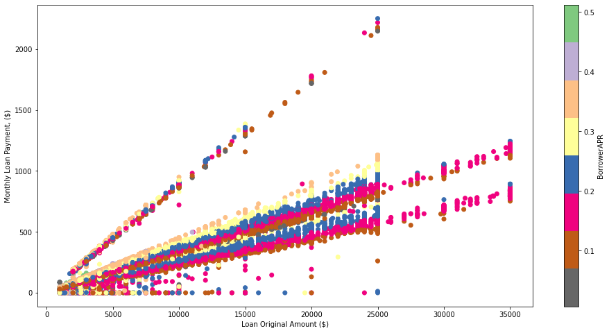

```python
plt.figure(figsize = (16, 8))

plt.scatter(data = df_clean, x = 'LoanOriginalAmount', y = 'MonthlyLoanPayment', c = 'BorrowerAPR',
           cmap = 'Accent_r')
plt.colorbar(label = 'BorrowerAPR')
plt.xlabel('Loan Original Amount ($)')
plt.ylabel('Monthly Loan Payment, ($)')

plt.show()
```

#### Observation:

> With the loan original amount correlating strongly with the monthly loan payment, majority of the borrowers had an APR between 0.1 and 0.4 charged on the range of the loan original amount.

### Exploration_M4

#### Question:

> What is the magnitude of the loan status on the loan original amount and the state from which a borrower comes from?

#### Visualization:

[figure not shown]

```python
base_color = sb.color_palette()[8]
g = sb.FacetGrid(data = df_clean, col = 'BorrowerState', height = 4, col_wrap = 3)
g.map(sb.violinplot, 'LoanStatus', 'LoanOriginalAmount', color = base_color)

plt.xlabel('Loan Status')
plt.ylabel('Loan Original Amount, ($)')

plt.show()
```

#### Observation:

> Completed, DefaultedLoanStatus and ChargedOff were the loan status that interacted with the borrower state across the range of the loan original amount. Different levels of the loan status distributed differently across the states. While some of the distributions were unimodal, others were multimodal. The median loan original amount was different for all the loan status levels of all the borrower states.

### Exploration_M5

#### Question:

> Does the ownership of a home by a borrower impact the loan original amount and the Monthly Loan Payment?

#### Visualization:

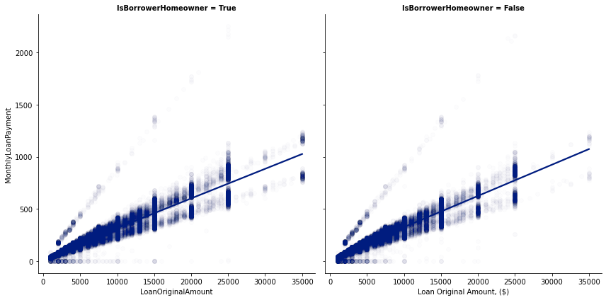

```python
g = sb.FacetGrid(data = df_clean, col = 'IsBorrowerHomeowner', height = 6)
g.map(sb.regplot, 'LoanOriginalAmount', 'MonthlyLoanPayment', scatter_kws={'alpha':1/100} )

plt.xlabel('Loan Original Amount, ($)')
plt.ylabel('Monthly Loan Payment')


plt.show()
```

#### Observation:

> Regardless of the status of ownership of a home by a borrower, the monthly loan payment increased with increasing loan original amount.